# Part 1. Reading and Understanding the Data

```python
import numpy as np
import pandas as pd

import matplotlib.pyplot as plt
import seaborn as sns
from matplotlib import rcParams
```

```python
rcParams['figure.figsize'] = 8, 5
sns.set_style('darkgrid')
```

```python
cars_df = pd.read_csv(filepath_or_buffer='car_data.csv')
cars_df.head()
```

|  | car_ID | symboling | CarName | fueltype | aspiration | doornumber | carbody | drivewheel | enginelocation | wheelbase | ... | enginesize | fuelsystem | boreratio | stroke | compressionratio | horsepower | peakrpm | citympg | highwaympg | price |
| --- | --- | --- | --- | --- | --- | --- | --- | --- | --- | --- | --- | --- | --- | --- | --- | --- | --- | --- | --- | --- | --- |
| 0 | 1 | 3 | alfa-romero giulia | gas | std | two | convertible | rwd | front | 88.6 | ... | 130 | mpfi | 3.47 | 2.68 | 9.0 | 111 | 5000 | 21 | 27 | 13495.0 |
| 1 | 2 | 3 | alfa-romero stelvio | gas | std | two | convertible | rwd | front | 88.6 | ... | 130 | mpfi | 3.47 | 2.68 | 9.0 | 111 | 5000 | 21 | 27 | 16500.0 |
| 2 | 3 | 1 | alfa-romero Quadrifoglio | gas | std | two | hatchback | rwd | front | 94.5 | ... | 152 | mpfi | 2.68 | 3.47 | 9.0 | 154 | 5000 | 19 | 26 | 16500.0 |
| 3 | 4 | 2 | audi 100 ls | gas | std | four | sedan | fwd | front | 99.8 | ... | 109 | mpfi | 3.19 | 3.40 | 10.0 | 102 | 5500 | 24 | 30 | 13950.0 |
| 4 | 5 | 2 | audi 100ls | gas | std | four | sedan | 4wd | front | 99.4 | ... | 136 | mpfi | 3.19 | 3.40 | 8.0 | 115 | 5500 | 18 | 22 | 17450.0 |

5 rows × 26 columns

```python
cars_df.describe()
```

|  | car_ID | symboling | wheelbase | carlength | carwidth | carheight | curbweight | enginesize | boreratio | stroke | compressionratio | horsepower | peakrpm | citympg | highwaympg | price |
| --- | --- | --- | --- | --- | --- | --- | --- | --- | --- | --- | --- | --- | --- | --- | --- | --- |
| count | 205.000000 | 205.000000 | 205.000000 | 205.000000 | 205.000000 | 205.000000 | 205.000000 | 205.000000 | 205.000000 | 205.000000 | 205.000000 | 205.000000 | 205.000000 | 205.000000 | 205.000000 | 205.000000 |
| mean | 103.000000 | 0.834146 | 98.756585 | 174.049268 | 65.907805 | 53.724878 | 2555.565854 | 126.907317 | 3.329756 | 3.255415 | 10.142537 | 104.117073 | 5125.121951 | 25.219512 | 30.751220 | 13276.710571 |
| std | 59.322565 | 1.245307 | 6.021776 | 12.337289 | 2.145204 | 2.443522 | 520.680204 | 41.642693 | 0.270844 | 0.313597 | 3.972040 | 39.544167 | 476.985643 | 6.542142 | 6.886443 | 7988.852332 |
| min | 1.000000 | -2.000000 | 86.600000 | 141.100000 | 60.300000 | 47.800000 | 1488.000000 | 61.000000 | 2.540000 | 2.070000 | 7.000000 | 48.000000 | 4150.000000 | 13.000000 | 16.000000 | 5118.000000 |
| 25% | 52.000000 | 0.000000 | 94.500000 | 166.300000 | 64.100000 | 52.000000 | 2145.000000 | 97.000000 | 3.150000 | 3.110000 | 8.600000 | 70.000000 | 4800.000000 | 19.000000 | 25.000000 | 7788.000000 |
| 50% | 103.000000 | 1.000000 | 97.000000 | 173.200000 | 65.500000 | 54.100000 | 2414.000000 | 120.000000 | 3.310000 | 3.290000 | 9.000000 | 95.000000 | 5200.000000 | 24.000000 | 30.000000 | 10295.000000 |
| 75% | 154.000000 | 2.000000 | 102.400000 | 183.100000 | 66.900000 | 55.500000 | 2935.000000 | 141.000000 | 3.580000 | 3.410000 | 9.400000 | 116.000000 | 5500.000000 | 30.000000 | 34.000000 | 16503.000000 |
| max | 205.000000 | 3.000000 | 120.900000 | 208.100000 | 72.300000 | 59.800000 | 4066.000000 | 326.000000 | 3.940000 | 4.170000 | 23.000000 | 288.000000 | 6600.000000 | 49.000000 | 54.000000 | 45400.000000 |

```python
cars_df.info()
```

```
<class 'pandas.core.frame.DataFrame'>
RangeIndex: 205 entries, 0 to 204
Data columns (total 26 columns):
 #   Column            Non-Null Count  Dtype
---  ------            --------------  -----
 0   car_ID            205 non-null    int64
 1   symboling         205 non-null    int64
 2   CarName           205 non-null    object
 3   fueltype          205 non-null    object
 4   aspiration        205 non-null    object
 5   doornumber        205 non-null    object
 6   carbody           205 non-null    object
 7   drivewheel        205 non-null    object
 8   enginelocation    205 non-null    object
 9   wheelbase         205 non-null    float64
```

[output cut: 18 more lines]

# Part 2. Data Cleaning and Preparation

```python
cars_df['car_company'] = cars_df['CarName'].apply(lambda x: x.split()[0].lower())

unique_companies = cars_df['car_company'].unique()
print(unique_companies)
```

```
['alfa-romero' 'audi' 'bmw' 'chevrolet' 'dodge' 'honda' 'isuzu' 'jaguar'
 'maxda' 'mazda' 'buick' 'mercury' 'mitsubishi' 'nissan' 'peugeot'
 'plymouth' 'porsche' 'porcshce' 'renault' 'saab' 'subaru' 'toyota'
 'toyouta' 'vokswagen' 'volkswagen' 'vw' 'volvo']
```

```python
cars_df['car_company'] = cars_df['car_company'].replace('toyouta', 'toyota')
cars_df['car_company'] = cars_df['car_company'].replace('porcshce', 'porsche')
cars_df['car_company'] = cars_df['car_company'].replace('maxda', 'mazda')
cars_df['car_company'] = cars_df['car_company'].replace('vokswagen', 'volkswagen')
cars_df['car_company'] = cars_df['car_company'].replace('vw', 'Volkswagen')

print(unique_companies)
```

```
['alfa-romero' 'audi' 'bmw' 'chevrolet' 'dodge' 'honda' 'isuzu' 'jaguar'
 'maxda' 'mazda' 'buick' 'mercury' 'mitsubishi' 'nissan' 'peugeot'
 'plymouth' 'porsche' 'porcshce' 'renault' 'saab' 'subaru' 'toyota'
 'toyouta' 'vokswagen' 'volkswagen' 'vw' 'volvo']
```

# Part 3. Visualising Categorical Data

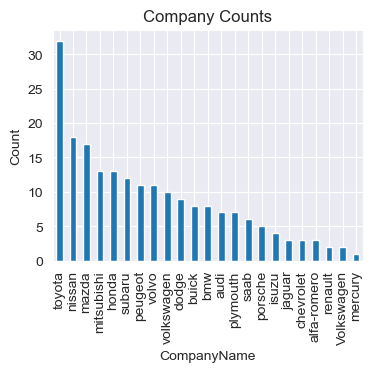

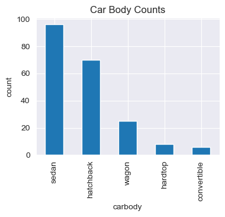

```python
'''
A plot of the unique company names on the x-axis, and the value counts on the y-axis.
A plot of the unique car bodys on the x-axis and value counts on the y-axis.
'''

plt.figure(figsize=(4, 3))
cars_df['car_company'].value_counts().plot(kind='bar')
plt.xlabel('CompanyName')
plt.ylabel('Count')
plt.title('Company Counts')
plt.show()

plt.figure(figsize=(4, 3))
cars_df['carbody'].value_counts().plot(kind='bar')
plt.ylabel('count')
plt.title('Car Body Counts')
plt.show()
```

**From these two plots, we are able to see the distribution and count of each unique company and unique car body . Here we can see that Toyota has a signicantly higher count than the other companies. From the Car Body Count graph, we see that sedan and hunchback take up a significant portion of the overall count.**

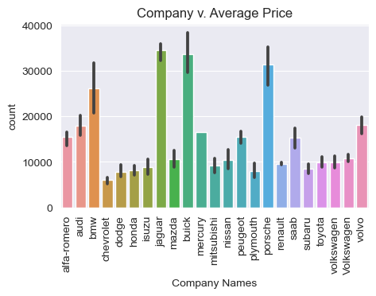

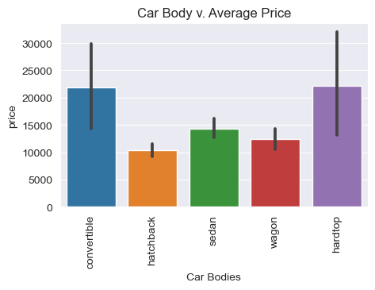

```python
'''
A plot of the unique company names on the x-axis, and that companies average price on the y-axis.
A plot of the unique car bodys on the x-axis and that car body's average price on the y-axis.
'''

plt.figure(figsize=(5, 3))
sns.barplot(data=cars_df, x='car_company', y='price')
plt.xlabel('Company Names')
plt.ylabel('count')
plt.title('Company v. Average Price')
plt.xticks(rotation=90)
plt.show()

plt.figure(figsize=(5, 3))
sns.barplot(data=cars_df, x='carbody', y='price')
plt.xlabel('Car Bodies')
plt.ylabel('price')
plt.title('Car Body v. Average Price')
plt.xticks(rotation=90)
plt.show()
```

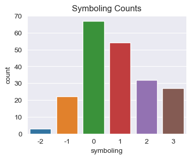

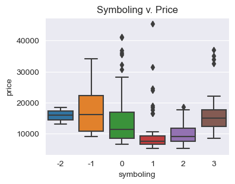

```python
'''
A plot of the unique symboling values on the x-axis, and the value counts on the y-axis.
A box plot of the unique symboling values on the x-axis and price on the y-axis.
'''

plt.figure(figsize=(4, 3))
sns.countplot(data=cars_df, x='symboling')
plt.xlabel('symboling')
plt.ylabel('count')
plt.title('Symboling Counts')
plt.show()

plt.figure(figsize=(4, 3))
sns.boxplot(data=cars_df, x='symboling', y='price')
plt.xlabel('symboling')
plt.ylabel('price')
plt.title('Symboling v. Price')
plt.show()
```

**From the symboling count graph, we see that most of the values fall on 0 or 1, meaning most of the cars in the dataset will be neutral or slightly risky. In the boxplot, we can see that cars with symboling below 0 have higher median values than those with positive symboling values indicating that the safety of a car does play a role in the price of a car.**

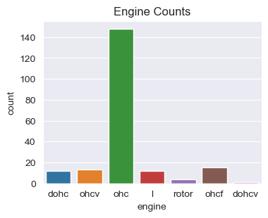

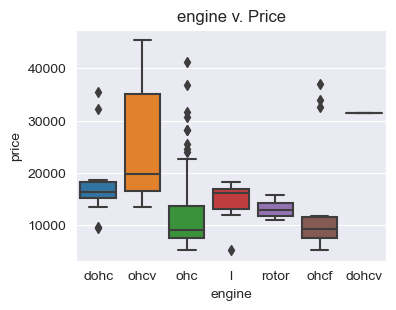

```python
'''
A plot of enginetype on the x-axis, and the value counts on the y-axis.
A box plot of enginetype on the x-axis and price on the y-axis.
'''

plt.figure(figsize=(4, 3))
sns.countplot(data=cars_df, x='enginetype')
plt.xlabel('engine')
plt.ylabel('count')
plt.title('Engine Counts')
plt.show()

plt.figure(figsize=(4, 3))
sns.boxplot(data=cars_df, x='enginetype', y='price')
plt.xlabel('engine')
plt.ylabel('price')
plt.title('engine v. Price')
plt.show()
```

**From the enginetype count graph, we conclude that a large majority of the enginetype of the observations of the dataset will be 'ohc' with over 140 counts. From the boxplot, we can see that ohcv has a very large range of values indicated by the two ends representing the minimum and maximum values, while dohc, rotor, ohcf, dohcv, and I engine have lower ranges.**

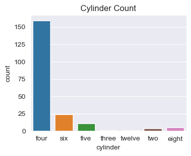

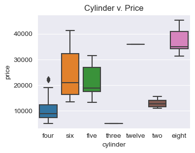

```python
'''
A plot of cylindernumber on the x-axis, and the value counts on the y-axis.
A box plot of cylindernumber on the x-axis and price on the y-axis.
'''

plt.figure(figsize=(4, 3))
sns.countplot(data=cars_df, x='cylindernumber')
plt.xlabel('cylinder')
plt.ylabel('count')
plt.title('Cylinder Count')
plt.show()

plt.figure(figsize=(4, 3))
sns.boxplot(data=cars_df, x='cylindernumber', y='price')
plt.xlabel('cylinder')
plt.ylabel('price')
plt.title('Cylinder v. Price')
plt.show()
```

**From the count graph, it seems a majority of cars have 4 cylinders amounting to above 150. According to the cylinder v. price graph, three and twelve cylinders seem to have no spread in values, while six has the largest spread.**

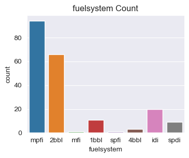

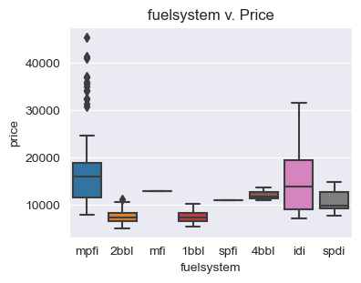

```python
'''
A plot of fuelsystem on the x-axis, and the value counts on the y-axis.
A box plot of fuelsystem on the x-axis and price on the y-axis.
'''

plt.figure(figsize=(4, 3))
sns.countplot(data=cars_df, x='fuelsystem')
plt.xlabel('fuelsystem')
plt.ylabel('count')
plt.title('fuelsystem Count')
plt.show()

plt.figure(figsize=(4, 3))
sns.boxplot(data=cars_df, x='fuelsystem', y='price')
plt.xlabel('fuelsystem')
plt.ylabel('price')
plt.title('fuelsystem v. Price')
plt.show()
```

**We can conclude that the fuel system that appears the most is mpfi and 2bbl. From the boxplot, we can see that mfi and spfi has no range, while idi has the largest range.**

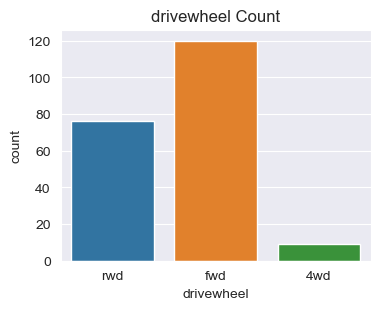

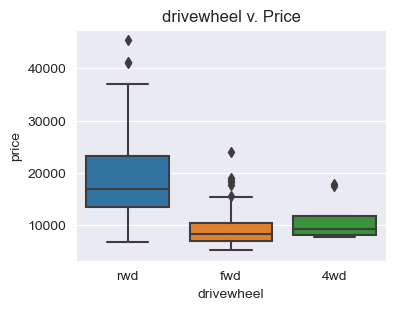

```python
'''
A plot of drivewheel on the x-axis, and the value counts on the y-axis.
A box plot of drivewheel on the x-axis and price on the y-axis.
'''

plt.figure(figsize=(4, 3))
sns.countplot(data=cars_df, x='drivewheel')
plt.xlabel('drivewheel')
plt.ylabel('count')
plt.title('drivewheel Count')
plt.show()

plt.figure(figsize=(4, 3))
sns.boxplot(data=cars_df, x='drivewheel', y='price')
plt.xlabel('drivewheel')
plt.ylabel('price')
plt.title('drivewheel v. Price')
plt.show()
```

**From the count graph, we see that most of the observations have rwd and fwd drivewheel while very little have 4wd. From the boxplot, we see that rwd has a very large range and the highest median value comparead to the other two fwd and 4wd.**

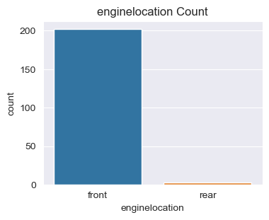

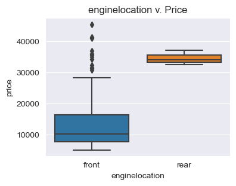

```python
'''
A plot of enginelocation on the x-axis, and the value counts on the y-axis.
A box plot of enginelocation on the x-axis and price on the y-axis.
'''

plt.figure(figsize=(4, 3))
sns.countplot(data=cars_df, x='enginelocation')
plt.xlabel('enginelocation')
plt.ylabel('count')
plt.title('enginelocation Count')
plt.show()

plt.figure(figsize=(4, 3))
sns.boxplot(data=cars_df, x='enginelocation', y='price')
plt.xlabel('enginelocation')
plt.ylabel('price')
plt.title('enginelocation v. Price')
plt.show()
```

**From the count graph, we see that most engines are located in the front rather than in the back. From the boxplot, we conclude that front engine location has a larger spread than back engine location, but back has a higher price overall.**

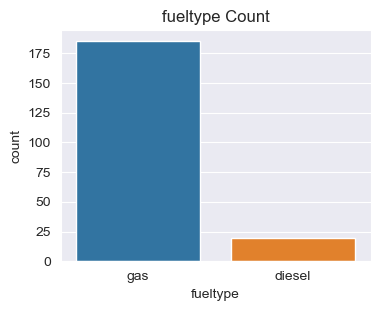

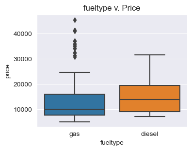

```python
'''
A plot of fueltype on the x-axis, and the value counts on the y-axis.
A box plot of fueltype on the x-axis and price on the y-axis.
'''

plt.figure(figsize=(4, 3))
sns.countplot(data=cars_df, x='fueltype')
plt.xlabel('fueltype')
plt.ylabel('count')
plt.title('fueltype Count')
plt.show()

plt.figure(figsize=(4, 3))
sns.boxplot(data=cars_df, x='fueltype', y='price')
plt.xlabel('fueltype')
plt.ylabel('price')
plt.title('fueltype v. Price')
plt.show()
```

**It seems from the count graph, that a majority of the vehicles are gas rather than diesel. From the box plot, it seems that diesel has a higher median value than gas meaning that in general, diesel vehicles are more expensive than gas vehicles.**

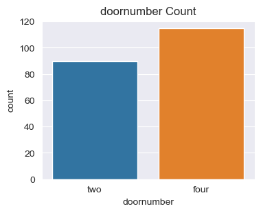

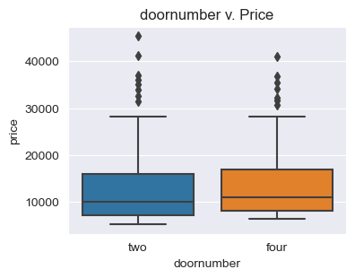

```python
'''
A plot of doornumber on the x-axis, and the value counts on the y-axis.
A box plot of doornumber on the x-axis and price on the y-axis.
'''

plt.figure(figsize=(4, 3))
sns.countplot(data=cars_df, x='doornumber')
plt.xlabel('doornumber')
plt.ylabel('count')
plt.title('doornumber Count')
plt.show()

plt.figure(figsize=(4, 3))
sns.boxplot(data=cars_df, x='doornumber', y='price')
plt.xlabel('doornumber')
plt.ylabel('price')
plt.title('doornumber v. Price')
plt.show()
```

**From the count graph, we see that more cars have four doors rather than two, but not that much of a difference. The boxplots between two and four doors are almost identical, but four door has a slightly higher median price value.**

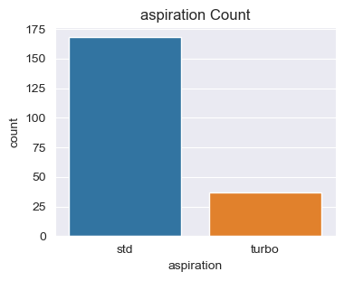

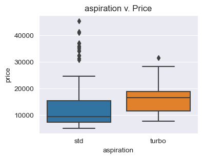

```python
'''
A plot of aspiration on the x-axis, and the value counts on the y-axis.
A box plot of aspiration on the x-axis and price on the y-axis.
'''

plt.figure(figsize=(4, 3))
sns.countplot(data=cars_df, x='aspiration')
plt.xlabel('aspiration')
plt.ylabel('count')
plt.title('aspiration Count')
plt.show()

plt.figure(figsize=(4, 3))
sns.boxplot(data=cars_df, x='aspiration', y='price')
plt.xlabel('aspiration')
plt.ylabel('price')
plt.title('aspiration v. Price')
plt.show()
```

**We see from the count graph that a majority of observations fall in the std category. From the box plot, we can conclude that the vehicles with turbo has a higher median value meaning that they are overall more expensive than the the vehicles with std.**

# Part 4. Visualising Numerical Data

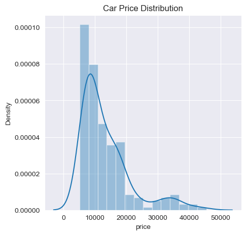

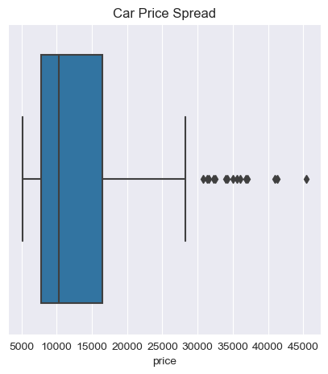

```python
plt.figure(figsize=(5, 5))
sns.distplot(cars_df['price'], kde=True)
plt.xlabel('price')
plt.title('Car Price Distribution')
plt.show()

plt.figure(figsize=(5,5))
sns.boxplot(data=cars_df, x='price')
plt.xlabel('price')
plt.title('Car Price Spread')
plt.show()
```

**From the distribution plot, we see that the graph is skewed right. While from the box plot, we can conclude that the spraed goes from 5000 to about 28000**

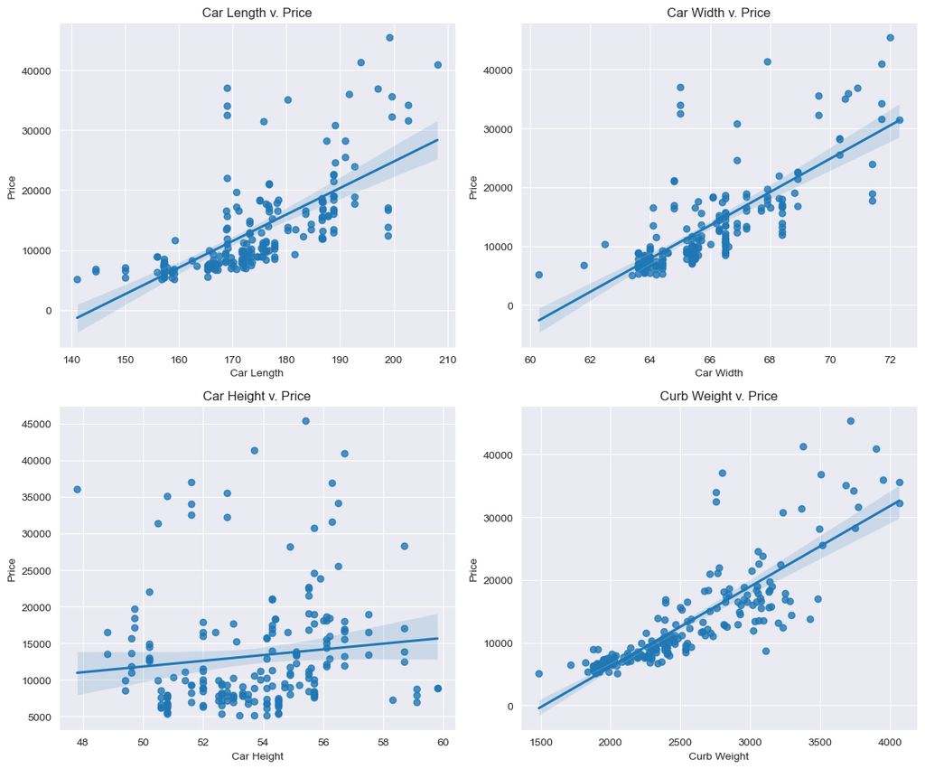

```python
fig, axs = plt.subplots(2, 2, figsize=(12, 10))

sns.regplot(x=cars_df['carlength'], y=cars_df['price'], ax=axs[0, 0])
axs[0, 0].set_xlabel('Car Length')
axs[0, 0].set_ylabel('Price')
axs[0, 0].set_title('Car Length v. Price')

sns.regplot(x=cars_df['carwidth'], y=cars_df['price'], ax=axs[0, 1])
axs[0, 1].set_xlabel('Car Width')
axs[0, 1].set_ylabel('Price')
axs[0, 1].set_title('Car Width v. Price')

sns.regplot(x=cars_df['carheight'], y=cars_df['price'], ax=axs[1, 0])
axs[1, 0].set_xlabel('Car Height')
axs[1, 0].set_ylabel('Price')
axs[1, 0].set_title('Car Height v. Price')

sns.regplot(x=cars_df['curbweight'], y=cars_df['price'], ax=axs[1, 1])
axs[1, 1].set_xlabel('Curb Weight')
axs[1, 1].set_ylabel('Price')
axs[1, 1].set_title('Curb Weight v. Price')

plt.tight_layout()
plt.show()
```

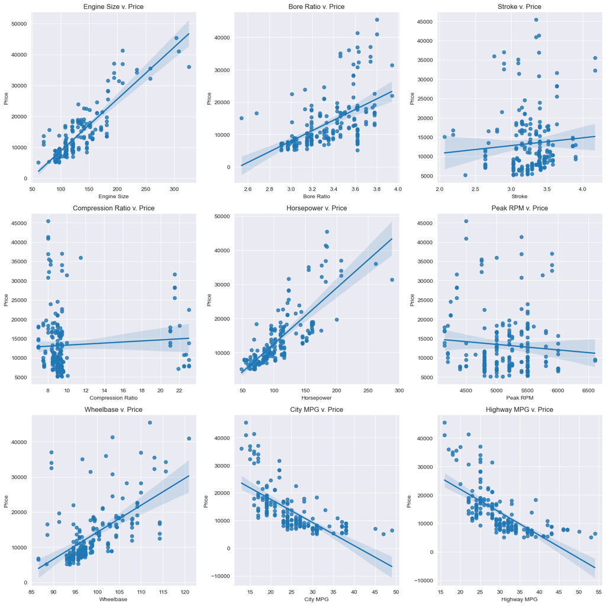

```python
import seaborn as sns
import matplotlib.pyplot as plt

# Assuming you have already loaded your dataframe `cars_df`

fig, axs = plt.subplots(3, 3, figsize=(15, 15))  # Creating a 3x3 grid of subplots

sns.regplot(x=cars_df['enginesize'], y=cars_df['price'], ax=axs[0, 0])
axs[0, 0].set_xlabel('Engine Size')
axs[0, 0].set_ylabel('Price')
axs[0, 0].set_title('Engine Size v. Price')

sns.regplot(x=cars_df['boreratio'], y=cars_df['price'], ax=axs[0, 1])
axs[0, 1].set_xlabel('Bore Ratio')
axs[0, 1].set_ylabel('Price')
axs[0, 1].set_title('Bore Ratio v. Price')

sns.regplot(x=cars_df['stroke'], y=cars_df['price'], ax=axs[0, 2])
axs[0, 2].set_xlabel('Stroke')
axs[0, 2].set_ylabel('Price')
axs[0, 2].set_title('Stroke v. Price')

sns.regplot(x=cars_df['compressionratio'], y=cars_df['price'], ax=axs[1, 0])
axs[1, 0].set_xlabel('Compression Ratio')
axs[1, 0].set_ylabel('Price')
axs[1, 0].set_title('Compression Ratio v. Price')

sns.regplot(x=cars_df['horsepower'], y=cars_df['price'], ax=axs[1, 1])
axs[1, 1].set_xlabel('Horsepower')
axs[1, 1].set_ylabel('Price')
axs[1, 1].set_title('Horsepower v. Price')

sns.regplot(x=cars_df['peakrpm'], y=cars_df['price'], ax=axs[1, 2])
axs[1, 2].set_xlabel('Peak RPM')
axs[1, 2].set_ylabel('Price')
axs[1, 2].set_title('Peak RPM v. Price')

sns.regplot(x=cars_df['wheelbase'], y=cars_df['price'], ax=axs[2, 0])
axs[2, 0].set_xlabel('Wheelbase')
axs[2, 0].set_ylabel('Price')
axs[2, 0].set_title('Wheelbase v. Price')

sns.regplot(x=cars_df['citympg'], y=cars_df['price'], ax=axs[2, 1])
axs[2, 1].set_xlabel('City MPG')
axs[2, 1].set_ylabel('Price')
axs[2, 1].set_title('City MPG v. Price')

sns.regplot(x=cars_df['highwaympg'], y=cars_df['price'], ax=axs[2, 2])
axs[2, 2].set_xlabel('Highway MPG')
axs[2, 2].set_ylabel('Price')
axs[2, 2].set_title('Highway MPG v. Price')

plt.tight_layout()  # Adjust layout to prevent overlapping
plt.show()
```

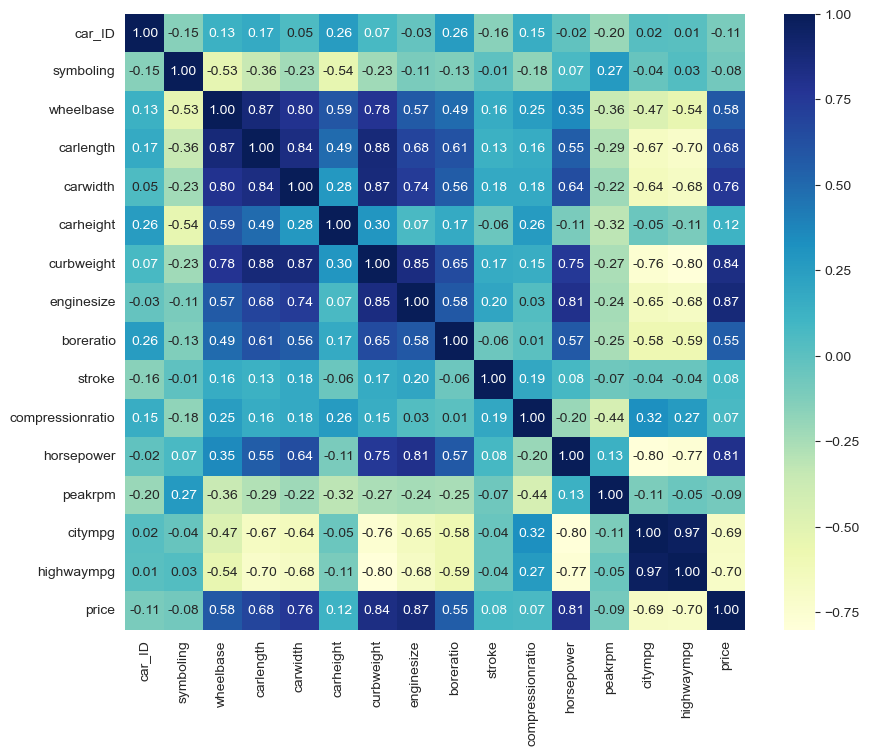

```python
correlation_matrix = cars_df.corr(numeric_only = True)

plt.figure(figsize=(10, 8))
sns.heatmap(correlation_matrix, annot=True, cmap='YlGnBu', fmt=".2f")
plt.show()
```

From the heatmap, the features I see that we could combine are highway and city MPG cause the correlation coefficient is .97. We could also try to combine those with absolute correlation coeffiecients higher than .85 like curbweight and carwidth or curbweight and carlength.

```python
cars_df['fuel_economy'] = ((cars_df['citympg'] * .55) + (cars_df['highwaympg'] * .45))
cars_df.head()
```

|  | car_ID | symboling | CarName | fueltype | aspiration | doornumber | carbody | drivewheel | enginelocation | wheelbase | ... | boreratio | stroke | compressionratio | horsepower | peakrpm | citympg | highwaympg | price | car_company | fuel_economy |
| --- | --- | --- | --- | --- | --- | --- | --- | --- | --- | --- | --- | --- | --- | --- | --- | --- | --- | --- | --- | --- | --- |
| 0 | 1 | 3 | alfa-romero giulia | gas | std | two | convertible | rwd | front | 88.6 | ... | 3.47 | 2.68 | 9.0 | 111 | 5000 | 21 | 27 | 13495.0 | alfa-romero | 23.70 |
| 1 | 2 | 3 | alfa-romero stelvio | gas | std | two | convertible | rwd | front | 88.6 | ... | 3.47 | 2.68 | 9.0 | 111 | 5000 | 21 | 27 | 16500.0 | alfa-romero | 23.70 |
| 2 | 3 | 1 | alfa-romero Quadrifoglio | gas | std | two | hatchback | rwd | front | 94.5 | ... | 2.68 | 3.47 | 9.0 | 154 | 5000 | 19 | 26 | 16500.0 | alfa-romero | 22.15 |
| 3 | 4 | 2 | audi 100 ls | gas | std | four | sedan | fwd | front | 99.8 | ... | 3.19 | 3.40 | 10.0 | 102 | 5500 | 24 | 30 | 13950.0 | audi | 26.70 |
| 4 | 5 | 2 | audi 100ls | gas | std | four | sedan | 4wd | front | 99.4 | ... | 3.19 | 3.40 | 8.0 | 115 | 5500 | 18 | 22 | 17450.0 | audi | 19.80 |

5 rows × 28 columns

According to the heatmap and correlation matrix, we can conclude that the best variables at predicting price are curbweight, engine size, and horsepower because of the correlation coefficients being .84, .87, and .81 respectively.

# Part 5. Data Pre-Processing

```python
from sklearn.model_selection import train_test_split
from sklearn.preprocessing import StandardScaler

categorical_variables = ['symboling', 'fueltype', 'enginetype', 'carbody', 'doornumber', 'enginelocation'
                        ,'fuelsystem', 'cylindernumber', 'aspiration', 'drivewheel']

dummy_cars_df = pd.get_dummies(cars_df, columns=categorical_variables)


to_be_scaled = [x for x in dummy_cars_df.columns if x not in ['car_ID', 'CarName', 'car_company']]

scaled_data = StandardScaler().fit_transform(dummy_cars_df[to_be_scaled])

scaled_cars_df = pd.DataFrame(scaled_data, columns = to_be_scaled)

y = scaled_cars_df['price']
X = scaled_cars_df.drop(columns = ['price'])

X_train, X_test, y_train, y_test = train_test_split(X, y, test_size=0.3, random_state=2024)
```

# Part 6. Model Creation and Evaluation

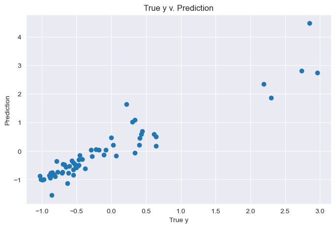

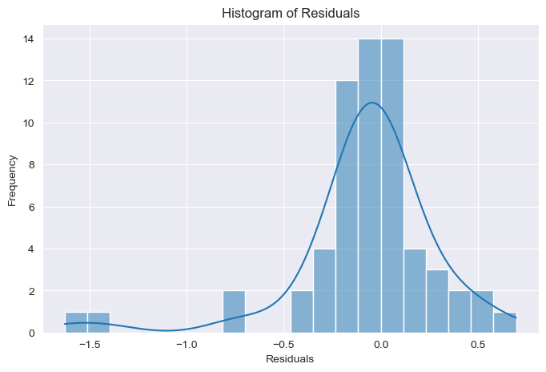

```
R^2 score: 0.8445788218986414
```

```python
from sklearn.linear_model import LinearRegression
from sklearn.metrics import r2_score


model = LinearRegression()
model.fit(X_train, y_train)

predictions = model.predict(X_test)

plt.scatter(y_test, predictions)
plt.xlabel('True y')
plt.ylabel('Prediction')
plt.title('True y v. Prediction')
plt.show()

residuals = y_test - predictions

sns.histplot(residuals, bins=20, kde = True)
plt.xlabel('Residuals')
plt.ylabel('Frequency')
plt.title('Histogram of Residuals')
plt.show()

r2 = r2_score(y_test, predictions)
print("R^2 score:", r2)
```

```python
coefficients = pd.DataFrame(model.coef_)
variables = pd.DataFrame(X.columns, columns=['Variable'])

result = pd.concat([variables, coefficients], axis=1)

display(result)
```

|  | Variable | 0 |
| --- | --- | --- |
| 0 | wheelbase | 5.914339e-03 |
| 1 | carlength | -7.825334e-02 |
| 2 | carwidth | 1.603103e-01 |
| 3 | carheight | 6.121231e-02 |
| 4 | curbweight | 2.815336e-01 |
| 5 | enginesize | 8.111782e-01 |
| 6 | boreratio | -2.015949e-01 |
| 7 | stroke | -2.312245e-01 |
| 8 | compressionratio | -5.002106e-02 |
| 9 | horsepower | 9.538287e-02 |
| 10 | peakrpm | 1.313510e-01 |
| 11 | citympg | -2.213844e-01 |
| 12 | highwaympg | 1.970871e-01 |
| 13 | fuel_economy | -2.794742e-02 |
| 14 | symboling_-2 | -7.730764e-02 |
| 15 | symboling_-1 | -1.420113e-02 |
| 16 | symboling_0 | 2.617421e-02 |
| 17 | symboling_1 | 2.298531e-02 |
| 18 | symboling_2 | -2.448296e-02 |
| 19 | symboling_3 | 4.821415e-04 |
| 20 | fueltype_diesel | 4.607786e-02 |
| 21 | fueltype_gas | -4.607786e-02 |
| 22 | enginetype_dohc | -2.766899e-02 |
| 23 | enginetype_dohcv | -7.678495e-02 |
| 24 | enginetype_l | -6.442815e-02 |
| 25 | enginetype_ohc | 1.386381e-01 |
| 26 | enginetype_ohcf | 4.789055e-02 |
| 27 | enginetype_ohcv | -2.325625e-01 |
| 28 | enginetype_rotor | 6.550685e-02 |
| 29 | carbody_convertible | 4.098685e-02 |
| 30 | carbody_hardtop | -2.635420e-02 |
| 31 | carbody_hatchback | -1.312766e-02 |
| 32 | carbody_sedan | 3.197049e-02 |
| 33 | carbody_wagon | -3.524439e-02 |
| 34 | doornumber_four | -1.421429e-02 |
| 35 | doornumber_two | 1.421429e-02 |
| 36 | enginelocation_front | -4.182486e-02 |
| 37 | enginelocation_rear | 4.182486e-02 |
| 38 | fuelsystem_1bbl | -1.799137e-02 |
| 39 | fuelsystem_2bbl | -3.374342e-03 |
| 40 | fuelsystem_4bbl | 1.682142e-02 |
| 41 | fuelsystem_idi | 4.607786e-02 |
| 42 | fuelsystem_mfi | -2.175231e-02 |
| 43 | fuelsystem_mpfi | 7.467904e-03 |
| 44 | fuelsystem_spdi | -5.987442e-02 |
| 45 | fuelsystem_spfi | 4.064715e-32 |
| 46 | cylindernumber_eight | 9.004247e-02 |
| 47 | cylindernumber_five | -4.878835e-02 |
| 48 | cylindernumber_four | -2.958929e-02 |
| 49 | cylindernumber_six | -2.135320e-02 |
| 50 | cylindernumber_three | 1.041009e-01 |
| 51 | cylindernumber_twelve | 2.898531e-32 |
| 52 | cylindernumber_two | 6.550685e-02 |
| 53 | aspiration_std | -2.495224e-02 |
| 54 | aspiration_turbo | 2.495224e-02 |
| 55 | drivewheel_4wd | -2.158806e-02 |
| 56 | drivewheel_fwd | -2.804690e-02 |
| 57 | drivewheel_rwd | 3.776489e-02 |

**From the coefficients, we can see the relationship between each feature and the price. If positive, we can see their is a positive linear relationship, if negative, its a negative linear relationship. We can also see the strength of each relationship based on the value.**